# POLS 1600: Random Variables, Probability Distributions, and Expected Values and Variances

## Geometric Distributions

What if we wanted to know the number times a coin came up tails before heads occurred? This discrete random variable follows a geometric distribution:

$$f(x)=p(1-p) ^{x}$$

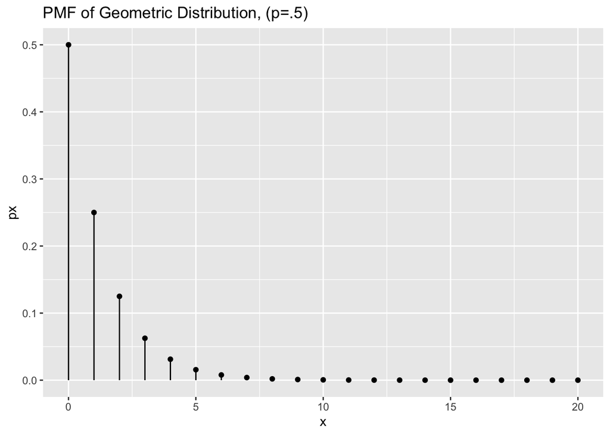

```r
df <- data.frame(x = 0:20, px = dgeom(0:20, .5))
ggplot(df,aes(x=x,y=px))+
         geom_point()+
         geom_segment(aes(x=x,xend=x,y=0,yend=px))+
  labs(title="PMF of Geometric Distribution, (p=.5)")
```

## Exponential Distributions

Taking a geometric distribution to its limit, you arrive at the continuous exponential distribution, again described by a $\lambda = \frac{1}{\beta}$ rate parameter

$$f(x)=\frac{1}{\beta}\exp\left[-x/\beta\right]$$

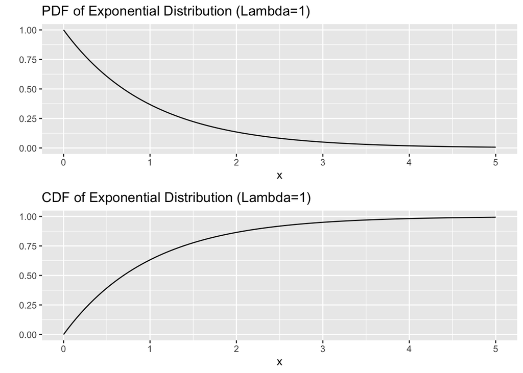

```r
p.pdf.exp<-ggplot(data.frame(x = c(0, 5)), aes(x)) + stat_function(fun = dexp)+ylim(0,1)+labs(title="PDF of Exponential Distribution (Lambda=1)",y="")
p.cdf.exp<-ggplot(data.frame(x = c(0, 5)), aes(x)) + stat_function(fun = pexp)+ylim(0,1)+labs(title="CDF of Exponential Distribution (Lambda=1)",y="")
grid.arrange(p.pdf.exp,p.cdf.exp)
```

We often use exponential distributions to model things like “time until failure” where failure might be another war or the ending of an Italian cabinet.

## Normal Distribution

Finally, there’s the distribution so ubiquitous we called it normal. The Normal distribution is defined by two parameters: a location parameter $\mu$ that determines the center of a distribution and a scale parameter $\sigma^2$ that determines the spread of a distribution

$$f(x)=\frac{1}{\sqrt{2\pi\sigma^2}}\exp \left[
-\frac{1}{2\sigma^2}(x-\mu)^2
\right]$$

Standard normal: $X \sim N(\mu =0,\sigma^2=1)$

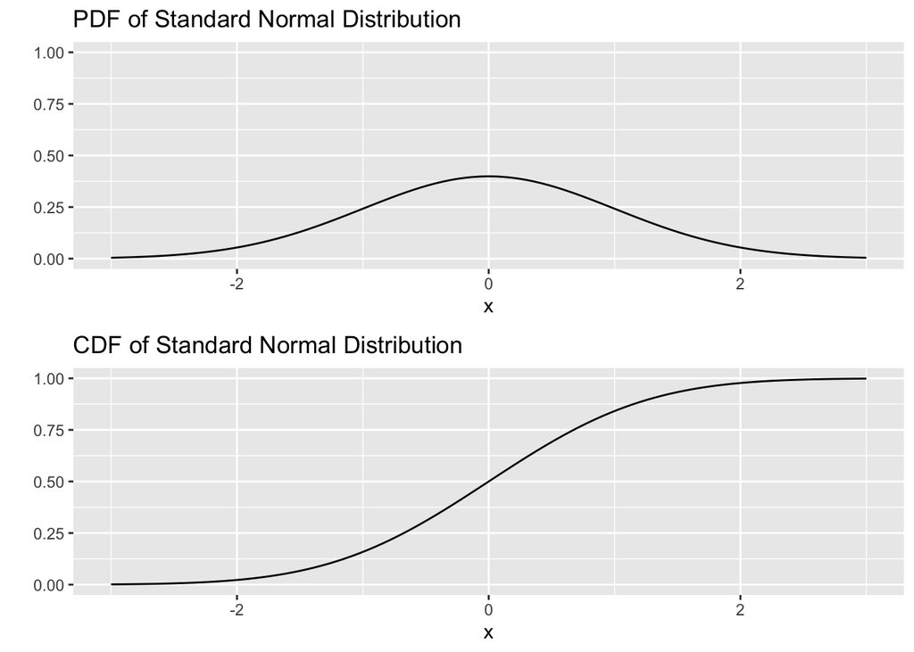

```r
p.pdf.norm<-ggplot(data.frame(x = c(-3, 3)), aes(x)) +
  stat_function(fun = dnorm,)+ylim(0,1)+
  labs(title="PDF of Standard Normal Distribution",y="")
p.cdf.norm<-ggplot(data.frame(x = c(-3, 3)), aes(x)) + stat_function(fun = pnorm)+ylim(0,1)+labs(title="CDF of Standard Normal Distribution",y="")
grid.arrange(p.pdf.norm,p.cdf.norm)
```

- As we’ll normal distributions tend to arise when ever you’re summing variables. That is sum together a bunch of values from almost any distribution and the **distribution of their sums** tends to follow a normal distribution. Since lots of our statistics involve summation, lots of our statistics will tend to follow normal distributions in their limit (in finite samples like the world we live in they may follow related distributions like the t-distribution, but more on that later.)

Consider a binomial distribution with N=100 and p=.5. The pmf of this variable (black lollipops) follows a distribution that’s closely approximated by a normal distribution (red line) with a mean 50 and a standard deviation of 5.

[figure not shown]

```r
p <- .5
df <- data.frame(x = 0:100, px = dbinom(0:100,size=100, prob=p))
ggplot(df,aes(x=x,y=px))+
         geom_point()+
         geom_segment(aes(x=x,xend=x,y=0,yend=px))+
  stat_function(fun = dnorm,args = list(50,sqrt(100*.5*(1-.5))), col="red")+
  labs(title="PMF of Binomial Distribution (N=20,P=.5)")
```

A relationship explained more generally by the Central Limit Theorem, which we’ll cover next week.

### What’s the p(X$\leq$ 0) for a normal distirbution with mean 0 and sd 1

Since the normal distribution is so common, it’s useful to get practice working with it’s pdf and cdf.

Consider the following question: If X is normally distributed variable with $\mu=0$ and $\sigma=1$, what’s the probability that X is less than 0 $p(X\leq0)=?$ We could solve:

$$\int_{-\infty}^{0}\frac{1}{\sqrt{2\pi}\sigma}e^{-\frac{1}{2}\left(\frac{x-\mu}{\sigma}\right)^2}dx=0.5$$

But R’s `pnorm()` function will quickly tell us

- $p(X\leq0)=$ 0.5

And we can visualize this as follows:

```
Warning: It is deprecated to specify `guide = FALSE` to remove a guide. Please use `guide = "none"`
instead.
```

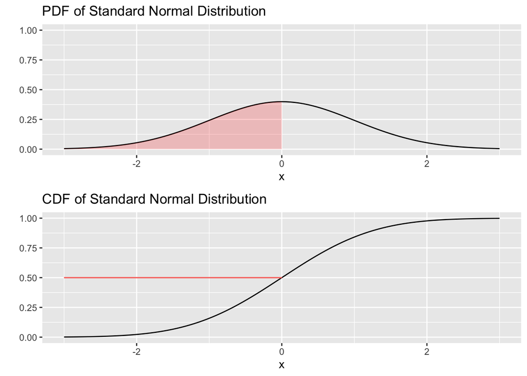

Consider some other questions?

- $p(X=0)=0$
  - The probability that a continuous variable is exactly some value is always 0.
- $p(X<0)=0.5$
- $p(-1< X< 1)$
- $p(-2< X< 2)$

### p(-1 < X < 1)

- $p(-1< X< 1)=pr(X<1)-pr(X<-1)$

$$\int_{-1}^{1}\frac{1}{\sqrt{2\pi}\sigma}e^{-\frac{1}{2}\left(\frac{x-\mu}{\sigma}\right)^2}dx=0.841-0.158=0.682$$

```
Warning: It is deprecated to specify `guide = FALSE` to remove a guide. Please use `guide = "none"`
instead.
```

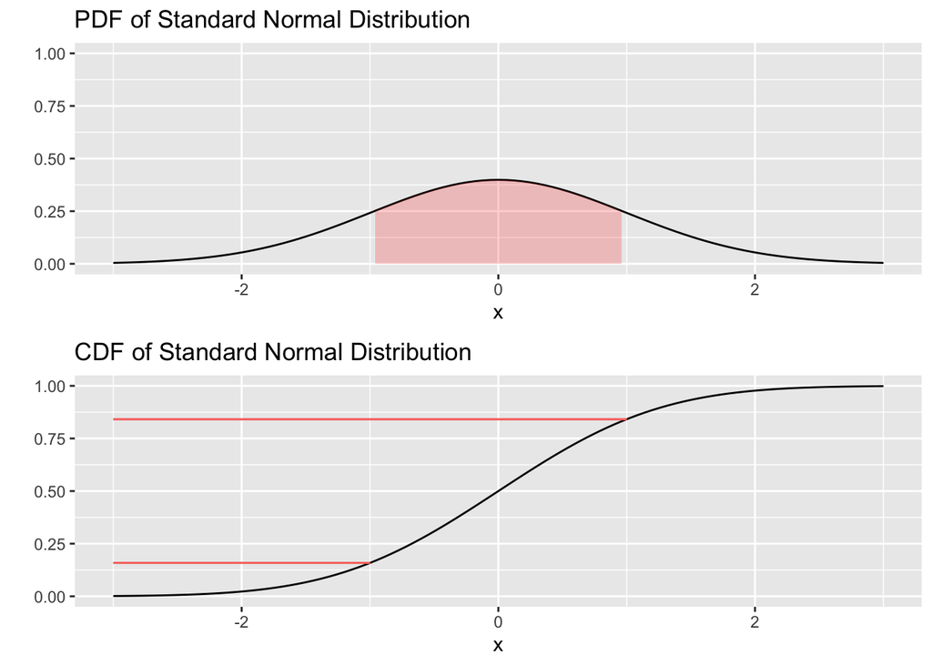

### p(-2 < X < 2)

- $p(-2< X\leq 2)=$ 0.9545

```
Warning: It is deprecated to specify `guide = FALSE` to remove a guide. Please use `guide = "none"`
instead.
```

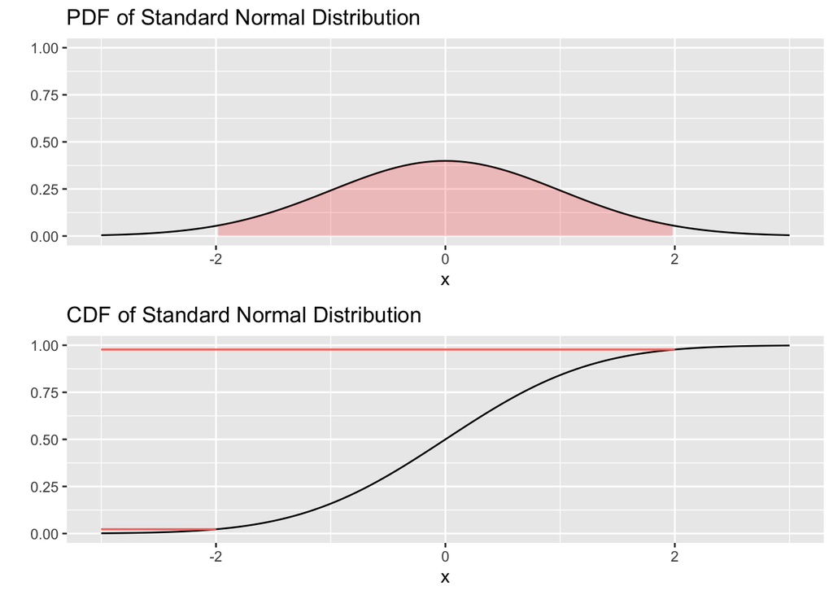

We’ll use the fact that close 95 of the observations of a standard normal variable will be within 2 standard deviations of the the mean of 0 for assessing whether a given statistic is likely to have arisen if the true value of that statistic were 0.

# Expected values and variances

## Expected Value

A (probability) weighted average of the possible outcomes of a random variable, often labeled $\mu$

Discrete:

$$\mu_X=E(X)=\sum xp(x)$$

Continuous
$$\mu_X=E(X)=\int_{-\infty}^{\infty}xf(x) dx$$

## What’s the expected value of a 1 roll of fair die?

$$\begin{align*}
E(X)&=\sum_{i=1}^{6}x_ip(x_i)\\
&=1/6\times(1+2+3+4+5+6)\\
&= 21/6\\
&=3.5
\end{align*}$$

## How many times would you have to roll a fair die to get all six sides?

We can think of this as the sum of the expected values for a series of geometric distributions with varying probabilities of success. The expected value of a geometric variable is:

$$\begin{align*}E(X)&=\sum_{k=1}^{\infty}kp(1-p)^{k-1} \\
&=p\sum_{k=1}^{\infty}k(1-p)^{k-1} \\
&=p\left(-\frac{d}{dp}\sum_{k=1}^{\infty}(1-p)^k\right) \text{(Chain rule)} \\
&=p\left(-\frac{d}{dp}\frac{1-p}{p}\right) \text{(Geometric Series)} \\
&=p\left(\frac{d}{dp}\left(1-\frac{1}{p}\right)\right)=p\left(\frac{1}{p^2}\right)=\frac1p\end{align*}$$

For this question, we need to calculate the probability of success, p, after getting a side we need.

The probability of getting a side you need on your first role is 1. The probability of getting a side you need on the second role, is 5/6 and so the expected number of roles is 6/5, and so the expected number of rolls to get all six is:

```r
ev <- c()
for(i in 6:1){
  ev[i] <- 6/i

}
# Expected rolls for each 1 through 6th side
rev(ev)
```

```
[1] 1.0 1.2 1.5 2.0 3.0 6.0
```

```r
# Total
sum(ev)
```

```
[1] 14.7
```

## Variance

If $X$ has a finite mean $E[X]=\mu$, the $E[(X-\mu)^2]$ is finite and called the variance of $X$ which we write as $\sigma^2$ or $Var[X]$.

Note:
$$\begin{align*}
\sigma^2=E[(X-\mu)^2]&=E[(X^2-2\mu X+\mu^2)]\\
&= E[X^2]-2\mu E[X]+\mu^2\\
&= E[X^2]-2\mu^2+\mu^2\\
&= E[X^2]-\mu^2\\
&= E[X^2]-E[X]^2
\end{align*}$$

- “The variance of X is equal to the expected value of X-squared, minus the square of X’s expected value.”
- $\sigma^2=E[X^2]-E[X]^2$ is a useful identity in proofs and derivations

## Variance and Standard Deviations

We often think of variances $Var[X]$ as describing the spread of a distribution

$$\sigma^2=Var[X]=E[(X-E[X])^2]=E(X^2)-E(X)^2$$

A standard deviation is just the square root of the variance

$$\sigma=\sqrt{Var[X]}$$

## Covariance

Covariance measures the degree to which two random variables vary together.

- $Cov[X,Y] \to +$ An increase in $X$ tends to be larger than its mean when $Y$ is larger than its mean

$$Cov[X,Y]=E[(X-E[X])(Y-E[Y])]=E[XY]-E[X]E[Y]$$

## Properties of Variance and Covariance

- $Cov[X,Y]=E[XY]-E[X]E[Y]$
- $Var[X]=E[X^2]-(E[X])^2$
- $Var[X|Y]=E[X^2|Y]-(E[X|Y])^2$
- $Cov[X,Y]=Cov[X,E[Y|X]]$
- $Var[X+Y]=Var[X]+Var[Y]+2Cov[X,Y]$
- $Var[Y]=Var[E[Y|X]]+E[Var[Y|X]]$

## Correlation

- The correlation between $X$ and $Y$ is simply the covariance of $X$ and $Y$ divided by the standard deviation of each.

$$\rho=\frac{Cov[X,Y]}{\sigma_X\sigma_Y}$$

- Normalize covariance to a scale that runs between [-1,1]

## Question: If two variables have zero covariance, are they independent?

No

A trivial example

- $p(X=x)=1/3$ for $x = -1,0,1$ and let $Y=X^2$
- Y clearly depends on X even though their covariance is 0

```r
p=1/3
x=-1:1
y=x^2
cor(x,y)
```

```
[1] 0
```